## Tell us what the future holds, so we may know that you are God.

```
                                                                  - Isiah 41:23
```

# What is a Time-Series ?

A time series is a series of data points indexed (or listed or graphed) in time order. Most commonly, a time series is a sequence taken at successive equally spaced points in time. Thus it is a sequence of discrete-time data.

# What is Time-Series Forecasting? (Predictive Analytics)

Time series forecasting is the use of a model to predict future values based on previously observed values.  
Example: Power demand of a city in the next 10 series.

# What is Time-series Analysis? (Descriptive Analytics)

Time series analysis comprises methods for analyzing time series data in order to extract meaningful statistics and other characteristics of the data.  
Example: Effect of sales of a restaurant due to demontisation.

## What can be Forecasted?

A few examples include:

- Building power generation plat in the next 5 years: Requires forecasts of future demand
- Scheduling staff in a call center next week requires forecasts of call volumes
- Stocking an inventory requires forecasts of stock requirements.

## Factors to consider while Forecasting?

- How much data is Available?
- How well we understand the factors that contribute to it?
- Weather the forecast can effect the things we are trying to forecast?

## Different kinds of forecasting?

- Short-term Forecasts
  - scheduling of personal.
  - production and transportation.
- Medium-term forecasts
  - Determine future resource requirements.
- Long-term forecasts
  - Strategic planning of a company.

## Forecast Horizons

- Will forecasts be required for next day, next week, next 6 months, next 10 years?
- How frequently are forecasts needed?
- What kind of forecasts are needed?

## Data Collections

- What data to include?
- Granularity of the data required based on the problem?
- How to gather data?
- Do we need external variables? What variables to include?

In a Forecasting project, spend most of the time collecting quality data.

**"GARBAGE IN. GARBAGE OUT"**

## Forecasting Types:

```
- Qualitative Forecating (Judgemental Foreacting)
- Quantitative ( Cross-sectional or Time-Series)
```

We will look into Time-Series Forecasting in this class

## Basic Steps in a forecasting task? (Convert this into a flow chart)

- step1: Defining problem
- step2: Gathering data
- step3: visualizing data
- step4: Building models
- step5: validating models and using them.

We have discussed briefly about defining a problem and gathering data previously. Now lets look into visualizing a time series data.

## VISUALISATION

```python
import pandas as pd
import numpy as np
import matplotlib.pyplot as plt
%matplotlib inline

import matplotlib
matplotlib.rc('xtick', labelsize=40)
matplotlib.rc('ytick', labelsize=40)

import seaborn as sns
sns.set(style="whitegrid", color_codes=True)

ts = pd.read_csv("data/AusAntidiabeticDrug.csv")
ts["ds"] = pd.to_datetime(ts["ds"])
print(ts.shape)
ts.head()
```

```
(204, 2)
```

|  | ds | y |
| --- | --- | --- |
| 0 | 1991-07-01 | 3.526591 |
| 1 | 1991-08-01 | 3.180891 |
| 2 | 1991-09-01 | 3.252221 |
| 3 | 1991-10-01 | 3.611003 |
| 4 | 1991-11-01 | 3.565869 |

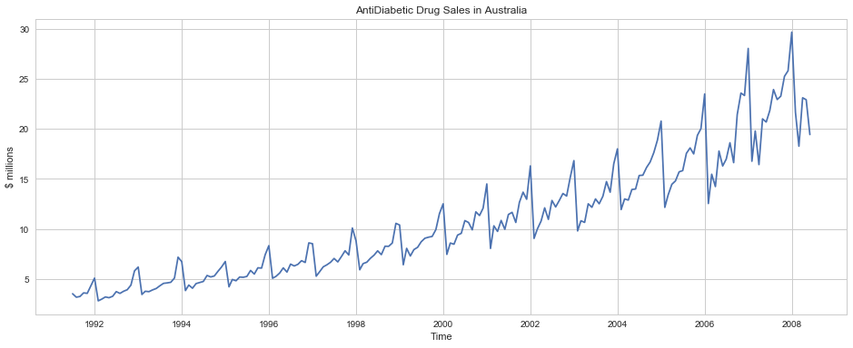

```python
plt.figure(figsize=(16, 6))
plt.plot(ts["ds"], ts["y"])
plt.xlabel("Time")
plt.ylabel("$ millions")
plt.title("AntiDiabetic Drug Sales in Australia")
```

## Insights - Time-Plot:

- There is a clear and increasing trend.
- There is also a strong seasonal pattern that increases in size as the level of the series increases.
- The sudden drop at the start of each year is caused by a government subsidisation scheme that makes it cost-effective for patients to stockpile drugs at the end of the calendar year.

**Any forecasts of this series would need to capture the seasonal pattern, and the fact that the trend is changing slowly.**

## Insights-Seasonal Plot

- There is a large jump in sales in January each year.
- The graph also shows that there was an unusually small number of sales in March 2008 (most other years show an increase between February and March).
- The small number of sales in June 2008 is probably due to incomplete counting of sales at the time the data were collected.

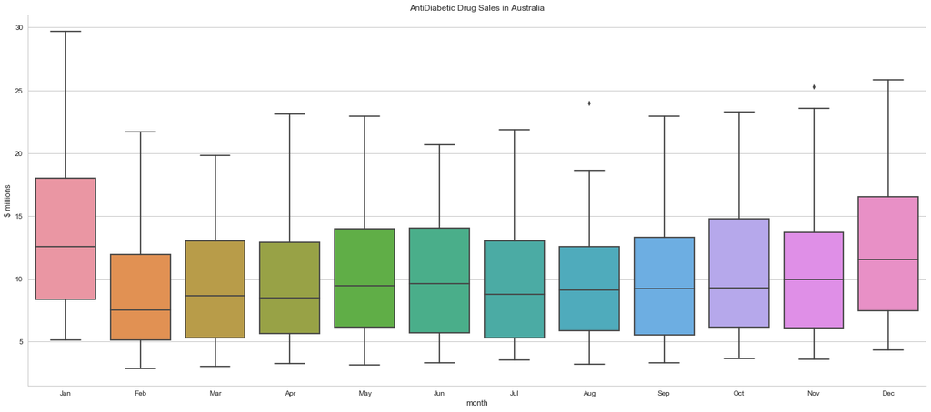

```python
plt.figure(figsize=(16, 7))
sns.factorplot(x="month", y="y", data=ts, kind="box", x_order=['Jan', 'Feb', 'Mar', 'Apr', 'May', 'Jun', 'Jul', 'Aug',
       'Sep', 'Oct', 'Nov', 'Dec'], size=8, aspect=float(16/7))
plt.xlabel("month")
plt.ylabel("$ millions")
plt.title("AntiDiabetic Drug Sales in Australia")
```

## LAGPLOTS

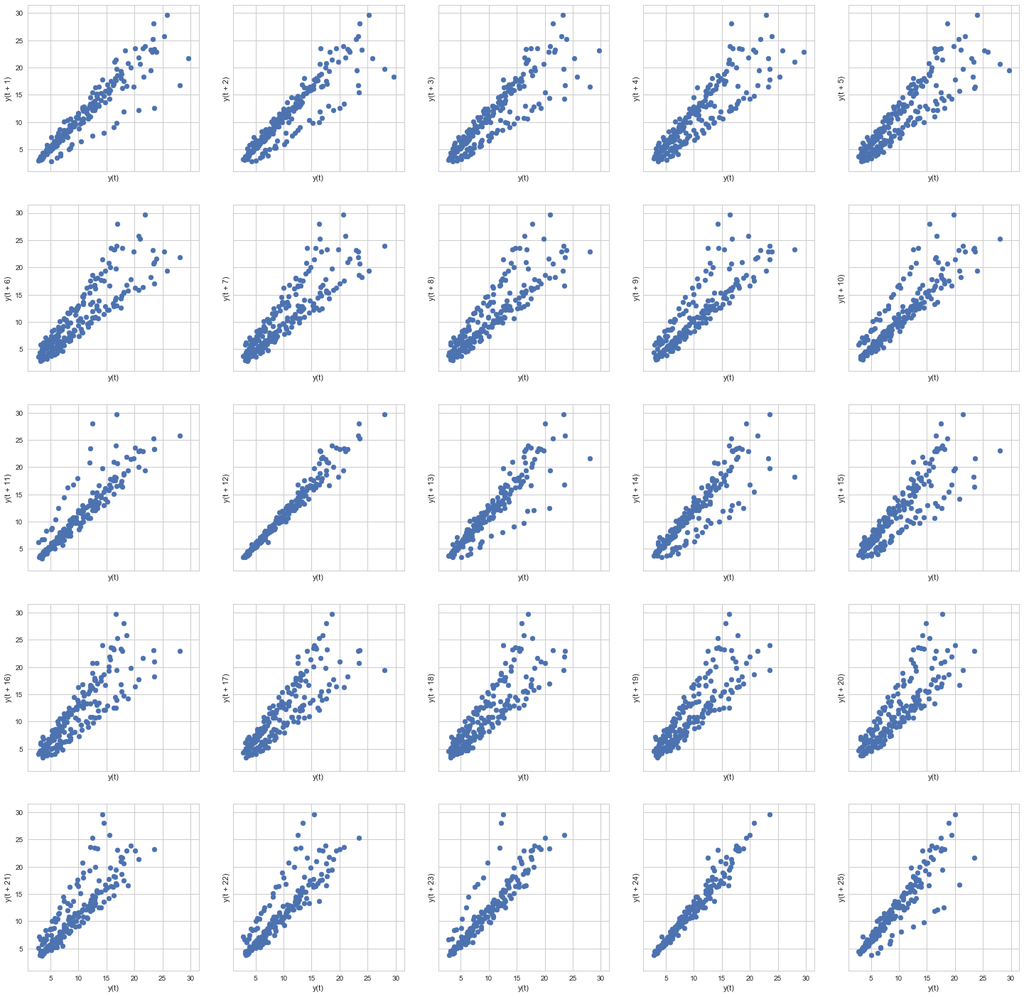

```python
from pandas.tools.plotting import lag_plot
plot_lags = 25
rows = int(plot_lags/5)
cols = int(plot_lags/5)
fig, axes = plt.subplots(rows, cols, sharex=True, sharey=True)
fig.set_figwidth(plot_lags)
fig.set_figheight(plot_lags)
count =1
for i in range(rows):
    for j in range(cols):
        lag_plot(ts["y"], lag=count, ax=axes[i, j])
        count+=1
```

## AutoCorrelation in Data

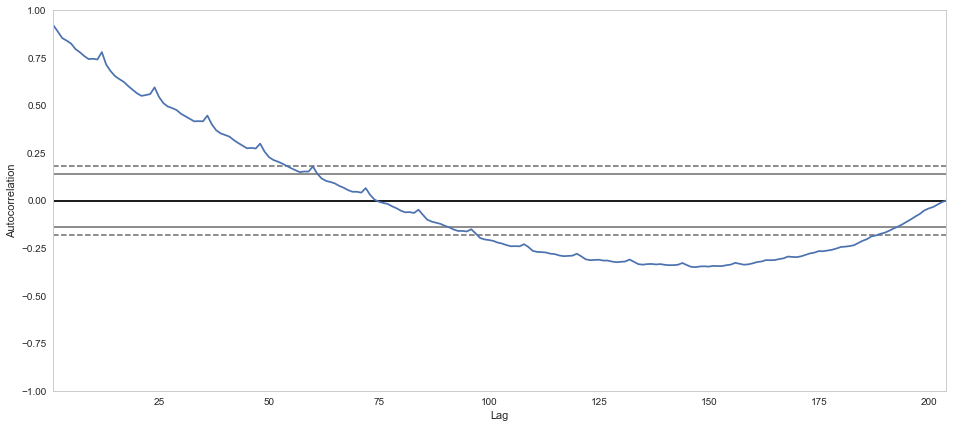

```python
from pandas.tools.plotting import autocorrelation_plot
plt.figure(figsize=(16, 7))
autocorrelation_plot(ts["y"])
```

## Decomposing your Time Series Data

- Trend
- Seasonality
- Residuals

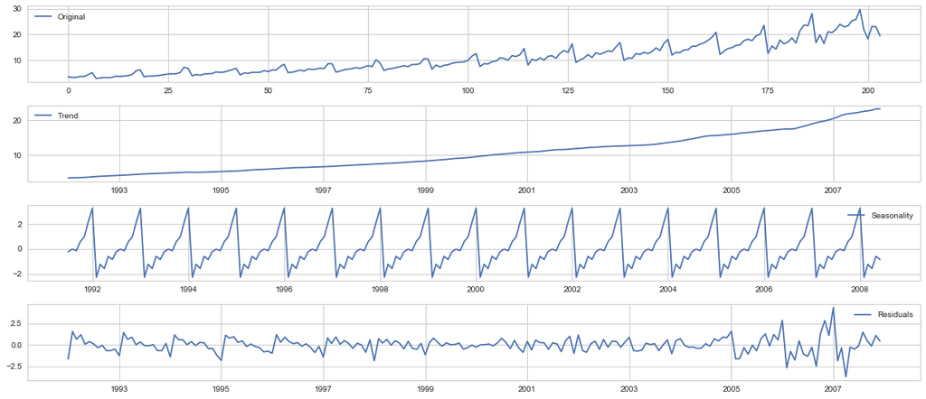

```python
from statsmodels.tsa.seasonal import seasonal_decompose
decomposition = seasonal_decompose(decompose)


trend = decomposition.trend
seasonal = decomposition.seasonal
residual = decomposition.resid
plt.figure(figsize=(16, 7))
plt.subplot(411)
plt.plot(ts["y"], label='Original')
plt.legend(loc='best')
plt.subplot(412)
plt.plot(trend, label='Trend')
plt.legend(loc='best')
plt.subplot(413)
plt.plot(seasonal,label='Seasonality')
plt.legend(loc='best')
plt.subplot(414)
plt.plot(residual, label='Residuals')
plt.legend(loc='best')
plt.tight_layout()
```